# Iconicity Experiment

Bonnie McLean

04/07/2020

# Crowd Sourcing

- Responses collected via [Prolific](https://www.prolific.co/) with people residing in the UK.
- Prolific is an online participant recruitment service comparable to MTurk but with less problems with bots and non-naieve participants, and better data quality than CrowdFlower (Peer et al. 2017). Of the three, Prolific also has the best conditions for workers as it enforces a minimum hourly wage and ensures that experiments cannot take longer to complete than advertised (participants can also see the average time taken to complete an experiment before accepting).
- It was created by British PhD students specifically for academic studies, and also has a lot more screening options than MTurk (e.g. you can choose to show your experiment only to English-speaking monolinguals in the UK)

# Informed consent

- The first page in the experiment tells them about the research and criteria for participation (i.e. that they do not speak or understand Japanese).
- Clicking ‘participate’ is taken as informed consent.

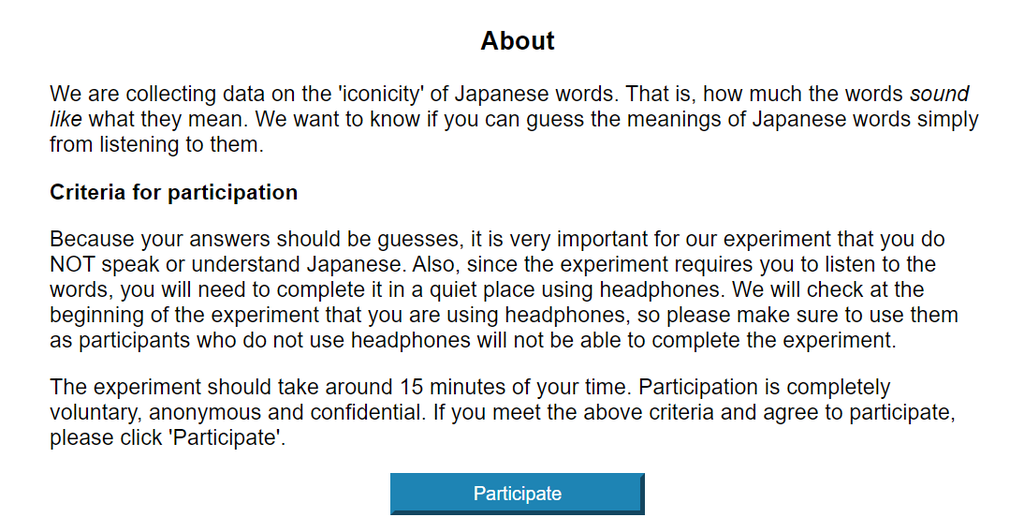

# Pre-Screening

- Before starting the experiment they have to take a test to check that they are using headphones. They listen to three audio files. Each audio file contains three pure tones of differing loudness, and they have to judge which is the quietest. The tones are modified so that this is easy to do when wearing headphones, but difficult without headphones (these are taken from Woods et al. 2017).
- If they get at least 2 of the three test items correct they can proceed to the experiment. If they score less than 2 correct then they’re directed to a page asking them to try again with headphones.

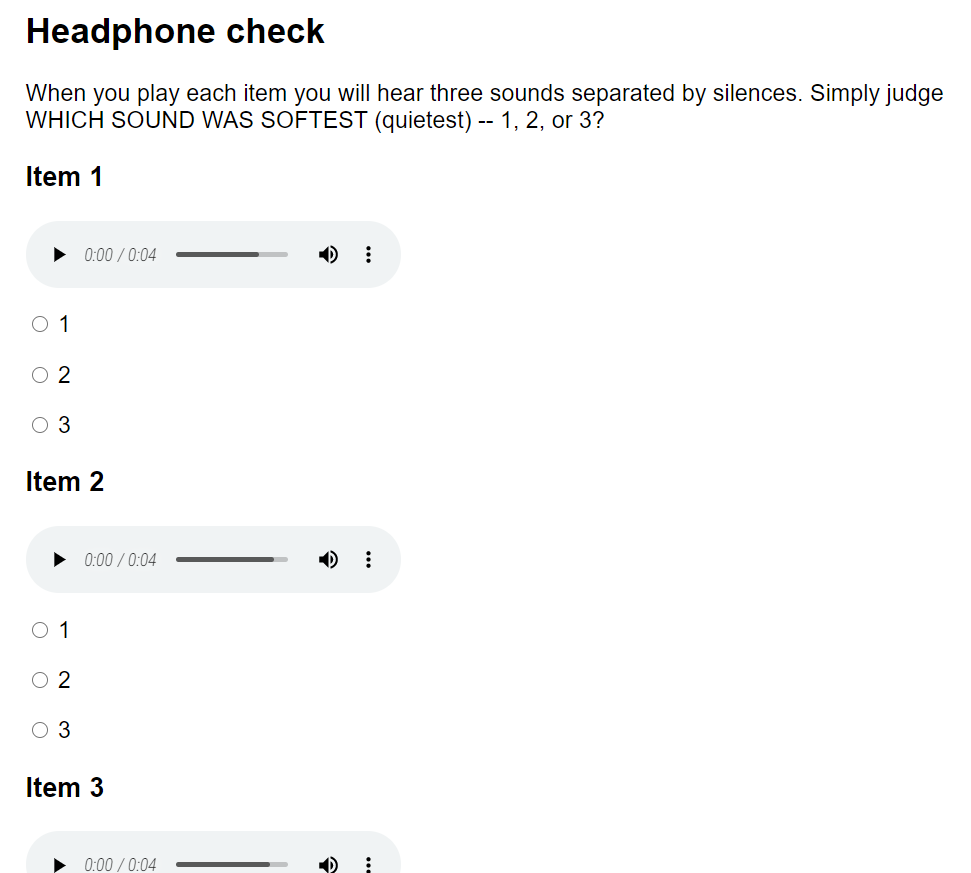

# Instructions

- Once they pass the headphone test, they see the following instructions and can then start the experiment:

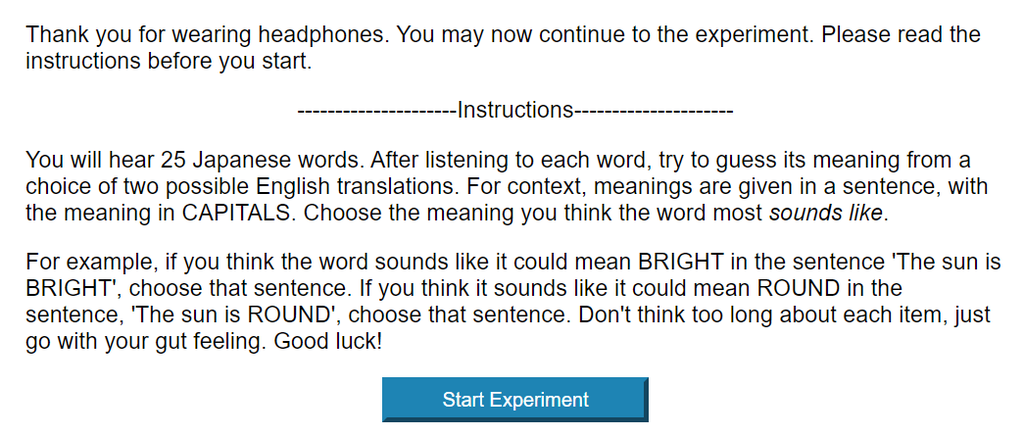

# Experiment format

- Each experiment consists of 25 trials.
- In each trial, participants listen to a recording of the word and are asked to guess its English translation from a choice of two translations which appear after they play the recording.
- For context, translations are given in sentences, with the translation word or phrase shown in capitals. This was necessary as many iconic words in Japanese have highly specific meanings that cannot adequately be captured in a single English word (Akita 2012).
- The sentences used to provide context to the translation all use the same formulaic template, ‘After X, Y’, where Y is the targeted sensory concept, and X is an event which produces it.
- Participants must choose between the correct translation and an incorrect translation randomly chosen from translations of other words within the same semantic domain, which are neither synonyms nor antonyms of the correct translation.
- **For each trial, we check that there is no phonological resemblance between the English translations and the Japanese word being tested, and that the iconicity and frequency of the translation words, and the length of the sentences, do not differ significantly between the options presented (see also D’Anselmo et al. 2019).**

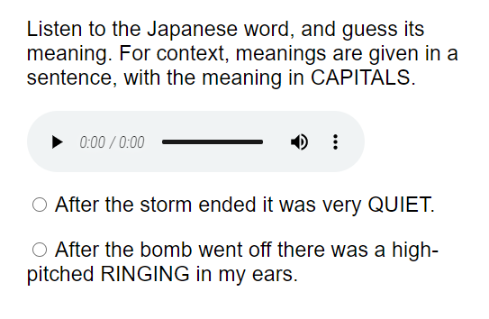

# Recordings

- Audio files generated using the Japanese [Google Cloud Text-to-Speech](https://cloud.google.com/text-to-speech) powered by Wavenet (unless you think it’s necessary to have a real native speaker record them? Because they’ll be resynthesised anyway).
- They are then manipulated in Praat to create resynthesised versions with a flat pitch contour, which are used for the experiment.

# Safeguards/quality checks

# Exit Survey

- Prolific ID
- Native language and any other languages they understand (although I can prescreen for this through Prolific, I thought it’s good to put it in anyway just to double check).
- Whether there were any words they didn’t understand in the translations, just to check that this isn’t a problem (because sometimes it’s hard to find an ‘easy’ English word to translate the ideophones, e.g. one sentence uses SLUGGISH which is maybe a bit uncommon).
- An attention check (describe what you were doing in this experiment?).

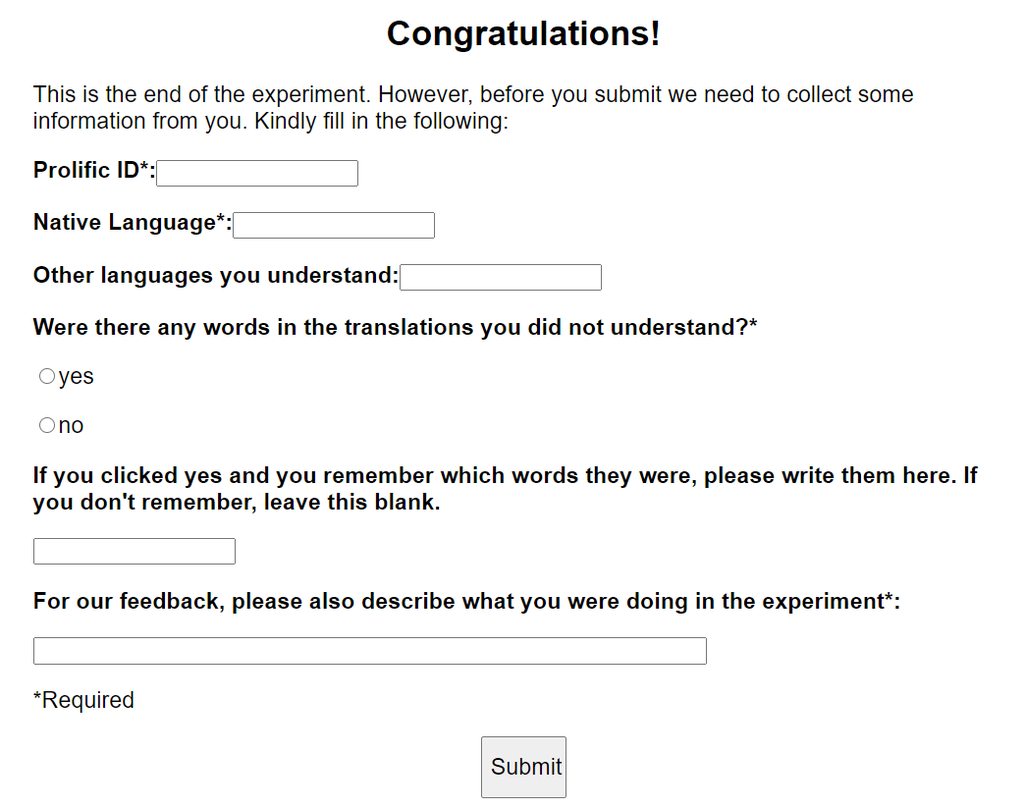

# Demo

- A demo of the experiment is available [here](https://bonniemclean.github.io/pilot).
- I haven’t finalised the sentences yet and still need to get my friend to record sound files.

# References

Akita, Kimi. 2012. “Toward a Frame-Semantic Definition of Sound-Symbolic Words: A Collocational Analysis of Japanese Mimetics.” *Cognitive Linguistics* 23 (1): 67–90.

D’Anselmo, Anita, Giulia Prete, Przemyslaw Zdybek, Luca Tommasi, and Alfredo Brancucci. 2019. “Guessing Meaning from Word Sounds of Unfamiliar Languages: A Cross-Cultural Sound Symbolism Study.” *Frontiers in Psychology* 10. https://doi.org/10.3389/fpsyg.2019.00593.

Kunihira, Shirou. 1971. “Effects of the Expressive Voice on Phonetic Symbolism.” *Journal of Verbal Learning and Verbal Behavior* 10 (4): 427–29. https://doi.org/10.1016/S0022-5371(71)80042-7.

Peer, Eyal, Laura Brandimarte, Sonam Samat, and Alessandro Acquisti. 2017. “Beyond the Turk: Alternative Platforms for Crowdsourcing Behavioral Research.” *Journal of Experimental Social Psychology* 70 (May): 153–63. https://doi.org/10.1016/j.jesp.2017.01.006.

Woods, Kevin J. P., Max Siegel, James Traer, and Josh H. McDermott. 2017. “Headphone Screening to Facilitate Web-Based Auditory Experiments.” *Attention, Perception & Psychophysics* 79 (7): 2064–72. https://doi.org/10.3758/s13414-017-1361-2.